# Analysis of Substance Abuse and Opioid Use Among Screened Inmates in Pennsylvania by Year and Gender

Ainsley Carlson

2025-09-30

## 2 Dataset Information

This dataset comes from the Pennsylvania Department of Corrections and consists of quartley data from 2016 to the current year by county. Dataset includes inmate admissions, average Texas Christian University Drug Screen II (TCU) score, number and percent of inmate admissions who identify opioids as top three drug of choice, inmates with a substance abuse problem, and number and percent who used opioids in the year prior to admission. There 7,722 observations and 20 variables within the dataset.

### 2.1 Variable Descriptions

Geographic Area [Character]: Name of State or County delineating the data that is shown in this row.

County Name [Character]: County name from which the inmate was sentenced to the Pennsylvania Department of Corrections.

Gender [Character]: This is All for both male and female or just male or female delineating the data in the row.

Age [Character]: The age group for the data in the row.

Year and Quarter [Character]: The Year and Quarter of the data in the row.

Time Period Dates [Character]: The beginning and end date of the data in the row.

Calendar Year of Data [Numeric]: year

Drug Screened Admissions [Numeric]: Total number of new commit admissions with valid Texas Christian University Drug Screen II (TCU) scores

Average TCU Drug Screen Score [Numeric]: Average score on the Texas Christian University Drug Screens (TCU) among Department of Corrections (DOC) admissions who have scores. The TCU assesses for substance abuse issues and provides a score between 0 and 9. A score of 3 or higher indicates a substance use disorder. Link: http://ibr.tcu.edu/wp-content/uploads/2016/10/TCU-Drug-Screen-II-sg-v11.pdf

New Admissions with Opioid Use [Numeric]: Number of new court admissions who used opiates as their top three drugs of choice, based on the TCU assessment results. The TCU Drug Screen II is scored to produce a single total score which can range from 0 to 9. Score values of 3 or greater indicate relatively severe drug-related problems, and correspond approximately to DSM drug dependence diagnosis. Responses to Item 10 indicate which drug (or drugs) the respondent feels is primarily responsible for his or her drug-related problems.

Percent of New Admissions with Opioid Use [Numeric]: Percent of total new court admissions who used opiates as their top three drugs of choice.

Admissions with Diagnosed Substance Abuse Problem [Numeric]: Number of new court admissions who had a TCU score of 3 or higher, indicating a substance abuse problem.The TCU Drug Screen II is scored to produce a single total score which can range from 0 to 9. Score values of 3 or greater indicate relatively severe drug-related problems, and correspond approximately to DSM drug dependence diagnosis. Responses to Item 10 indicate which drug (or drugs) the respondent feels is primarily responsible for his or her drug-related problems.

Percent of Admissions with Diagnosed Substance Abuse Problem [Numeric]: Percent of new court admissions who had a TCU score of 3 or higher, indicating a substance abuse problem. The TCU Drug Screen II is scored to produce a single total score which can range from 0 to 9. Score values of 3 or greater indicate relatively severe drug-related problems, and correspond approximately to DSM drug dependence diagnosis. Responses to Item 10 indicate which drug (or drugs) the respondent feels is primarily responsible for his or her drug-related problems.

Admissions with Opioid use in past 12 months [Numeric]: Number of new court admissions who self identified as using Opiates or Heroin in the prior 12 months before admission to DOC.

Percent of Admissions with Opioid use in past 12 months [Numeric]: Percent of total new court admissions who self identified as using Opiates or Heroin in the prior 12 months before admission to DOC

State FIPS [Numeric]: These are the first 2 digits of the 5-digit Federal Information Processing Standard (FIPS) code that designate the State association.

County FIPS [Numeric]: The 3-digit part of the 5-digit county FIPS code specifically standing for the county.

Latitude [Character]: A generic Latitude point within the county. A point is also provided for outside of the state (on a map it will sit to the southeast of the state). This number represents the total number for the state and this location provides a spot on a map to display the PA number without having it duplicate within a county when using in a mapping visual.

Longitude [Character]: A generic Longitude point within the county. A point is also provided for outside of the state (on a map it will sit to the southeast of the state). This number represents the total number for the state and this location provides a spot on a map to display the PA number without having it duplicate within a county when using in a mapping visual.

Georeferenced Latitude &Longitude [Character]:A generic georeferenced Latitude & Longitude point within the county. These points can be used to create visualizations such as maps to show the data by county. A point is also provided for outside of the state (on a map it will sit to the southeast of the state). This number represents the total number for the state and this location provides a spot on a map to display the PA number without having it duplicate within a county when using in a mapping visual.

## 3 Missing Values

None of the variables have missing values except for “Georeferenced Lattitude &Longitude”, which is not a variable of interest in out analysis. Therefore, there is no concern about what should be done with missing values and can proceed with the analysis.

### 3.1 Exploratory Data Analysis

#### 3.1.1 Gender

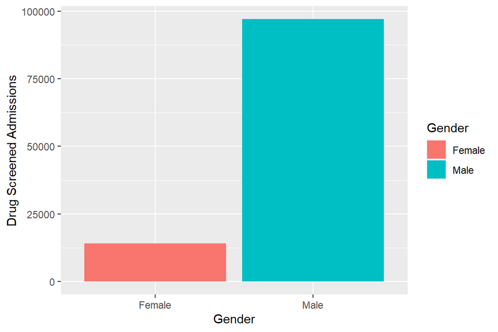

#### 3.1.2 New admissions with Diagnised Substance Abuse Problems

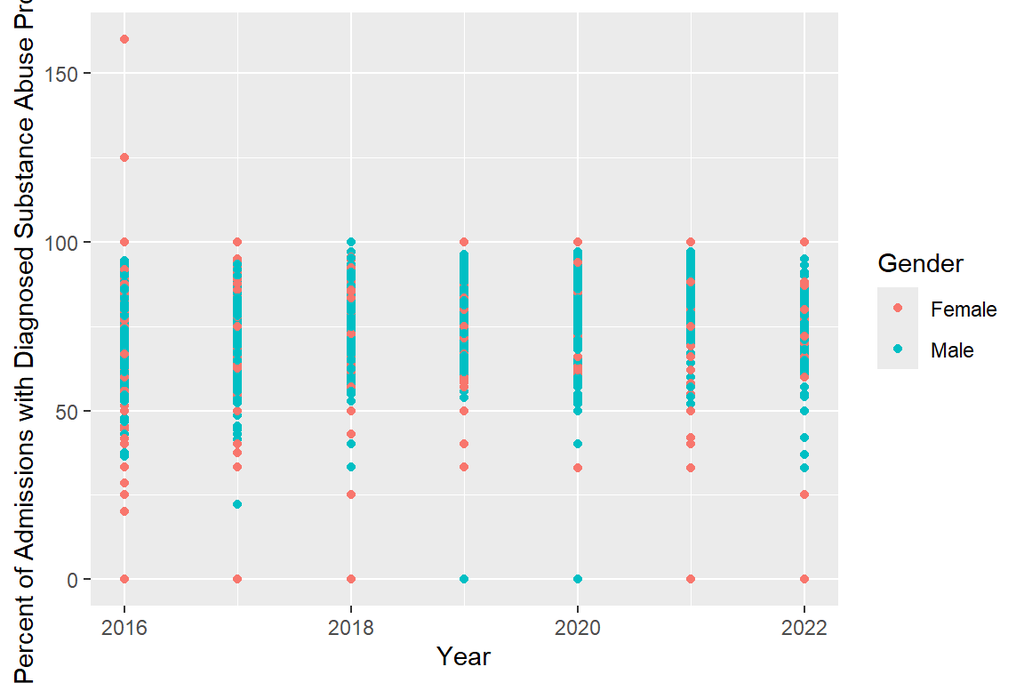

```
## # A tibble: 14 × 3
## # Groups:   Year [7]
##     Year Gender  name
##    <dbl> <chr>  <dbl>
##  1  2016 Female  61.7
##  2  2016 Male    69.8
##  3  2017 Female  62.3
##  4  2017 Male    70.7
##  5  2018 Female  70.1
##  6  2018 Male    73.4
##  7  2019 Female  73.5
##  8  2019 Male    77.8
##  9  2020 Female  65.0
## 10  2020 Male    74.3
## 11  2021 Female  68.9
## 12  2021 Male    79.0
## 13  2022 Female  66.9
## 14  2022 Male    71.6
```

Looking at the scatterplot of the percent of admissions with a substance abuse problem it is not clear if men or women have a higher percentage of substance abuse problems, but looking at the means show that men have a higher avrage percentage of prison admissions with a substance abuse problem. The percentage of new admissions with a substance abuse problem seem to skew higher than those with opioid use, which makes sense as all those classified with opioid use are classified as having a substance abuse problem, but not all those with a substance abuse problem have used opioids. Additionally there appear to be two outliers in 2016 that have a percentage above 100%, which is not plausible.

#### 3.1.3 New Admissions with Opioid Use by Year and Gender

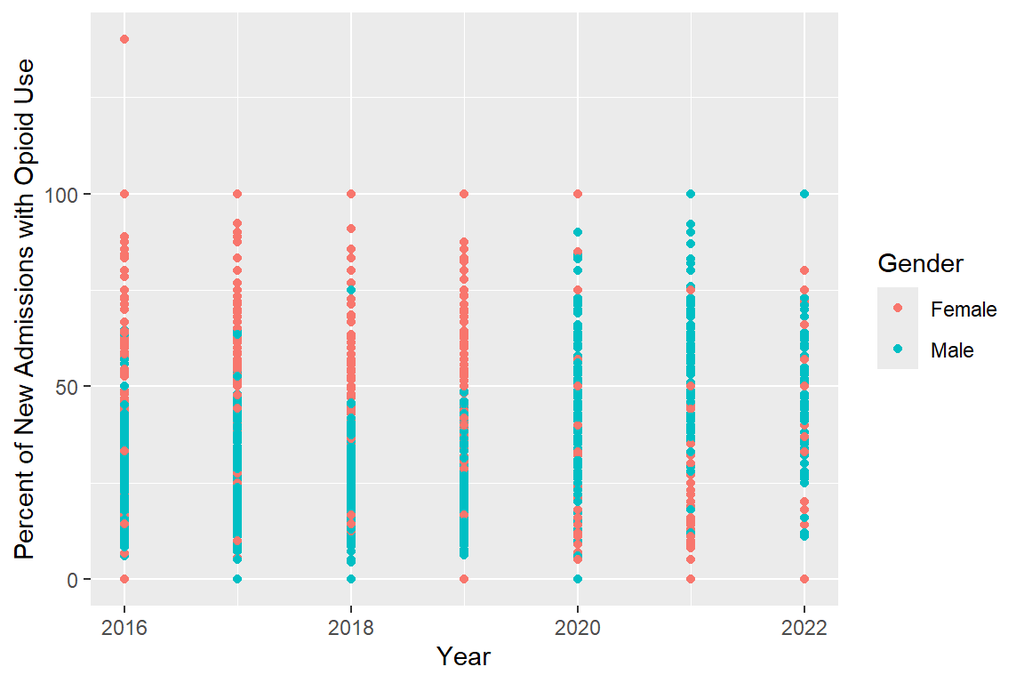

```
## # A tibble: 14 × 3
## # Groups:   Year [7]
##     Year Gender  name
##    <dbl> <chr>  <dbl>
##  1  2016 Female  45.0
##  2  2016 Male    27.5
##  3  2017 Female  44.3
##  4  2017 Male    25.6
##  5  2018 Female  41.8
##  6  2018 Male    24.9
##  7  2019 Female  39.4
##  8  2019 Male    24.4
##  9  2020 Female  16.7
## 10  2020 Male    40.2
## 11  2021 Female  23.3
## 12  2021 Male    51.7
## 13  2022 Female  24.1
## 14  2022 Male    43.1
```

Looking at the scatterplot of the percent of new admissions with opoid use from 2016 to 2022 by gender shows that between 2016 and 2019 a higher percentage of women had opiod use than men. However, in 2020 it seems that on average there may be a higher percentage of men with opiod use than women. This is confirmed by looking at the averages by gender and year as there are a higher percentage of men with opioid use than women. There also appears to be an outlier for women in 2016 with a percentage greater than 100%, which should not be possible.

## 4 Feature Engineering

### 4.1 Percent of Admissions with Diagnosed Substance Abuse Problem versus Scatterplot of Percent of New Admissions with Opioid Use

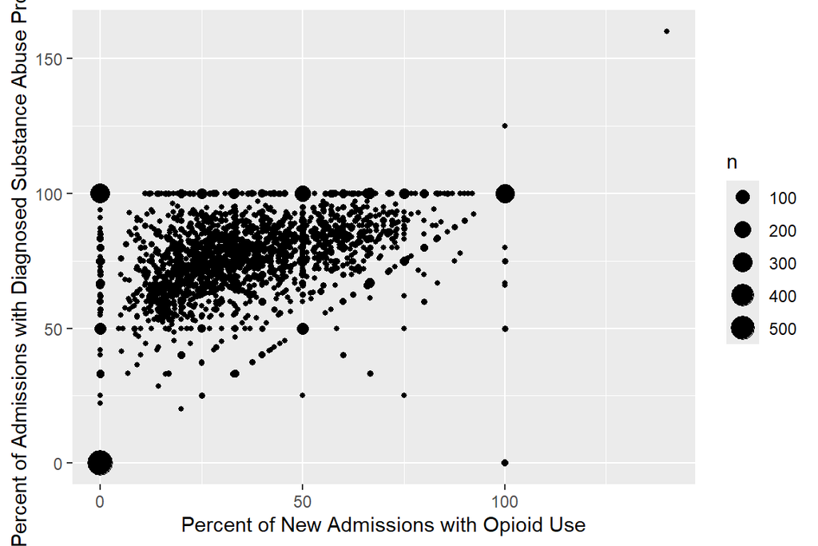

With the exception of two outliers, most of the data appears to be in the upper triangular area of the graph. This can be interpreted as most observations having a higher percentage of inmates with a diagnose substance abuse problem than new admissions with opioid use. There appear to be a large number of observations at (0,0), (0,100), and (100,100), which could influence the regression model. For this analysis, I made the decision to remove observations where there were zero inmates screened as all of those observations would be at the point (0,0). Filtering them out will help with the density of observations at the point (0,0) and will give a more accurate analysis of the relationship between the percentage of inmate with a diagnosed substance abuse problem and the percentage of inmates with opioid use. For similar reason, I also filtered out instances where there was only one inmate screened as the percentage can only take on values of 0, or 100, which can also skew the endpoints to be heavier. By filtering out these instance I aim to make the data to look more normlly distributed as oppossed being a tail heavy distribution.

Additionally, I will filter out counties that are equal to “Commonwealth” as that is a summation of all the counties in Pennsylvania. Similarly, I will be removing observations where gender is equal to “All” because they are summations of male and female. The year variable will be recoded to be categorcial, with 2016 being the reference category as I am interested if there is difference in the relationship between years.

#### 4.1.1 Percentage of Admissions with Diagnosd Substance Abuse Outliers

Filtering the data for the outliers shows that female admissions in Columbia county in 2016 is responsible for one of the outliers due to the same reason for the outlier with opioid use. The other outlier comes from quarter 1 of 2016 in Delaware county when 12 admissions were screened, but 15 had a substance abuse problem. The one for Columbia county should be corrected after correcting for the issue with opioid use percentage, and a similar approach will be used for Delaware county as well.

#### 4.1.3 Percentage of New Admissions with Opioid Use Outliers

Filtering the data shows that the outlier again comes from Columbia county in quarter 1 of 2016 for women as they had 5 drug screened admissions, but 7 new admissions with opioid use. Furthermore, in quarter 1 of 2016 there were 4 new female admissions with opioid us, but there were no drug screened admissions. As the average TCU drug screen score is 5.5 for quarter 1 of 2016, it seems likely that there were new admissions screened.

#### 4.1.4 Delaware County Female 2016 Quarter 1 Outlier

###### 4.1.4.0.1 Delaware County Descriptive Statistics of Drug Screened Admissions

```
##    Min. 1st Qu.  Median    Mean 3rd Qu.    Max.
##    11.0    14.0    18.0    19.6    23.5    34.0
```

###### 4.1.4.0.2 Delaware County Descriptive Statistics of Percent of Admissions with Diagnosed Substance Abuse Problem

```
##    Min. 1st Qu.  Median    Mean 3rd Qu.    Max.
##   60.90   74.15   80.00   78.70   85.00   90.00
```

###### 4.1.4.0.3 Delaware County Descriptive Statistics of Percent of New Admissions with Opioid Use

```
##    Min. 1st Qu.  Median    Mean 3rd Qu.    Max.
##   43.50   47.45   50.00   53.19   56.95   73.30
```

The percent of female admissions in Delaware County with a diagnosed substance abuse problem, excluding quarter 1 of 2016 is between 60.9% and 90% with a median of 80%. The number of drug screened admissions is between 11 and 34 with a median of 18. By adjusting the number of drug screened admissions for women in Delaware county in quarter one of 2016 from 12 to 19, both the percentage of new admissions with opioid use and admissions with substance abuse issues will be close to to the median.

#### 4.1.5 Columbia County Female 2016 Quarter 1 Outlier

###### 4.1.5.0.1 Columbia County Descriptive Statistics of Drug Screened Admissions

```
##    Min. 1st Qu.  Median    Mean 3rd Qu.    Max.
##     0.0     0.0     3.0     2.0     3.5     5.0
```

###### 4.1.5.0.2 Columbia County Descriptive Statistics of Percent of Admissions with Diagnosed Substance Abuse Problem

```
##    Min. 1st Qu.  Median    Mean 3rd Qu.    Max.
##    0.00    0.00  100.00   57.78  100.00  100.00
```

###### 4.1.5.0.3 Columbua County Descriptive Statistics of Percent of New Admissions with Opioid Use

```
##    Min. 1st Qu.  Median    Mean 3rd Qu.    Max.
##    0.00    0.00   33.30   34.55   63.35  100.00
```

Keeping the number of new admissions with opioid use as 4 and the number with substance abuse as 3, it would be appropriate to change the number of drug screened admissions to 5. Doing so would allow the percentage of inmates with a diagnosed substance abuse to be around 60%, and 80% for the percentage of new admissions with opiod use. This ensures that all values are plausible values for females in Columbia county.

## 5 Linear Regression

### 5.1 Baseline Linear Regression

```
##
## Call:
## lm(formula = as.numeric(`Percent of Admissions with Diagnosed Substance Abuse Problem`) ~
##     `Percent of New Admissions with Opioid Use` + `Year Category`,
##     data = pa_educ_add_mod)
##
## Residuals:
##     Min      1Q  Median      3Q     Max
## -73.026  -9.242   0.504  10.243  37.132
##
## Coefficients:
##                                             Estimate Std. Error t value
## (Intercept)                                 62.86837    0.92285  68.124
## `Percent of New Admissions with Opioid Use`  0.26888    0.01252  21.479
## `Year Category`2017                          2.51443    1.11063   2.264
## `Year Category`2018                          6.77229    1.10468   6.131
## `Year Category`2019                          9.94596    1.10553   8.997
## `Year Category`2020                         10.15806    1.15097   8.826
## `Year Category`2021                          8.48070    1.14014   7.438
## `Year Category`2022                          5.38463    1.22513   4.395
##                                             Pr(>|t|)
## (Intercept)                                  < 2e-16 ***
## `Percent of New Admissions with Opioid Use`  < 2e-16 ***
## `Year Category`2017                           0.0237 *
## `Year Category`2018                         9.99e-10 ***
## `Year Category`2019                          < 2e-16 ***
## `Year Category`2020                          < 2e-16 ***
## `Year Category`2021                         1.35e-13 ***
## `Year Category`2022                         1.15e-05 ***
## ---
## Signif. codes:  0 '***' 0.001 '**' 0.01 '*' 0.05 '.' 0.1 ' ' 1
##
## Residual standard error: 16.28 on 2798 degrees of freedom
## Multiple R-squared:  0.1759, Adjusted R-squared:  0.1739
## F-statistic: 85.33 on 7 and 2798 DF,  p-value: < 2.2e-16
```

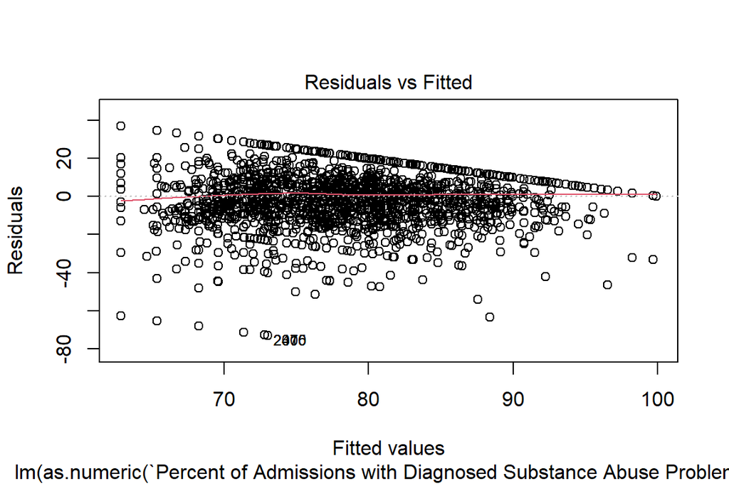

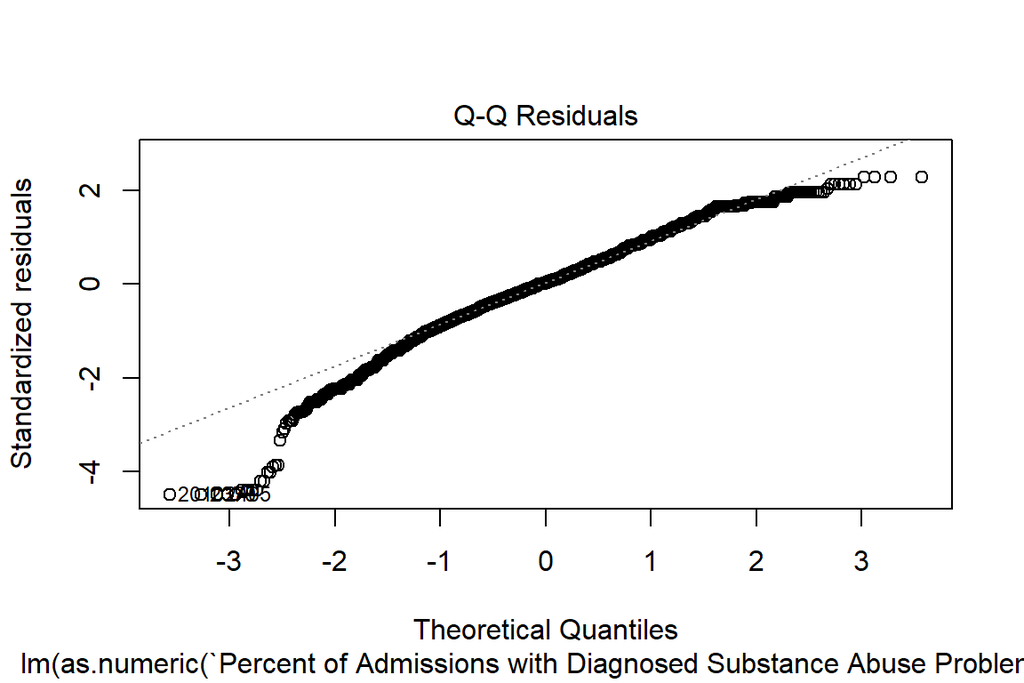

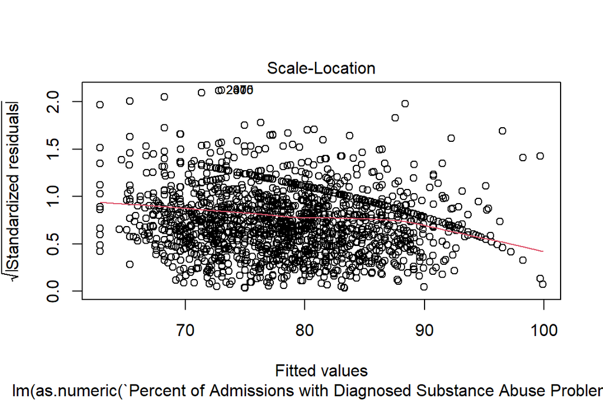

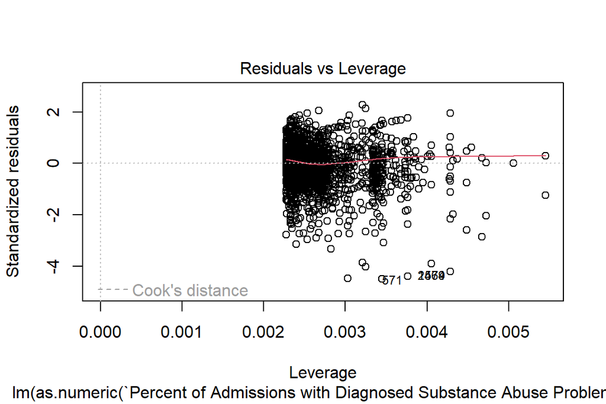

For the first linear regression, I only include the variables related to the relationship I wish to analysize. For this model analyzing the relationship between the percentage of admissions with a substance abuse problem and the percentage of new admissions with opioid use controlling for year, all of the variables are significantly different from zero at the p=0.05 level. On average, a 1 percentage point increase in the percent of new admissions with opioid use leads to a 0.27 percentage point increase in the percent of admissions with a substance abuse problem. Looking at the residual plot of the model shows there to be no extreme outliers, but the Q-Q plot show the residuals to be tail heavy. Performing a Box-Cox transformation on the model shows the ideal transformation to be close to 2, so I will include a squared term of the explanatory variable in the model to see if that improves the residual plots.

#### 5.1.1 Box-Cox Transformation

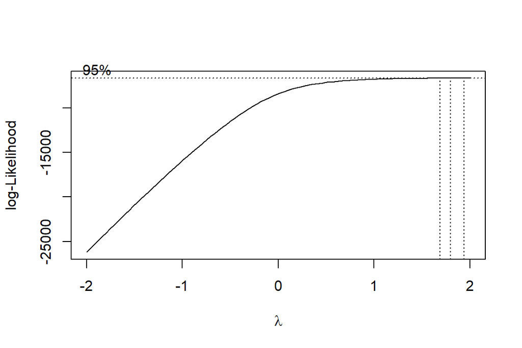

```
##
## Call:
## lm(formula = `Percent of Admissions with Diagnosed Substance Abuse Problem` ~
##     `Percent of New Admissions with Opioid Use Squared` + `Percent of New Admissions with Opioid Use` +
##         `Year Category`, data = pa_educ_add_mod)
##
## Residuals:
##     Min      1Q  Median      3Q     Max
## -74.234  -9.084   0.470  10.529  35.784
##
## Coefficients:
##                                                      Estimate Std. Error
## (Intercept)                                         6.422e+01  1.063e+00
## `Percent of New Admissions with Opioid Use Squared` 9.792e-04  3.841e-04
## `Percent of New Admissions with Opioid Use`         1.816e-01  3.645e-02
## `Year Category`2017                                 2.477e+00  1.110e+00
## `Year Category`2018                                 6.771e+00  1.104e+00
## `Year Category`2019                                 9.925e+00  1.104e+00
## `Year Category`2020                                 1.002e+01  1.151e+00
## `Year Category`2021                                 8.422e+00  1.139e+00
## `Year Category`2022                                 5.393e+00  1.224e+00
##                                                     t value Pr(>|t|)
## (Intercept)                                          60.422  < 2e-16 ***
## `Percent of New Admissions with Opioid Use Squared`   2.550   0.0108 *
## `Percent of New Admissions with Opioid Use`           4.981 6.71e-07 ***
## `Year Category`2017                                   2.232   0.0257 *
## `Year Category`2018                                   6.136 9.68e-10 ***
## `Year Category`2019                                   8.986  < 2e-16 ***
## `Year Category`2020                                   8.702  < 2e-16 ***
## `Year Category`2021                                   7.393 1.89e-13 ***
## `Year Category`2022                                   4.406 1.09e-05 ***
## ---
## Signif. codes:  0 '***' 0.001 '**' 0.01 '*' 0.05 '.' 0.1 ' ' 1
##
## Residual standard error: 16.27 on 2797 degrees of freedom
## Multiple R-squared:  0.1778, Adjusted R-squared:  0.1755
## F-statistic: 75.62 on 8 and 2797 DF,  p-value: < 2.2e-16
```

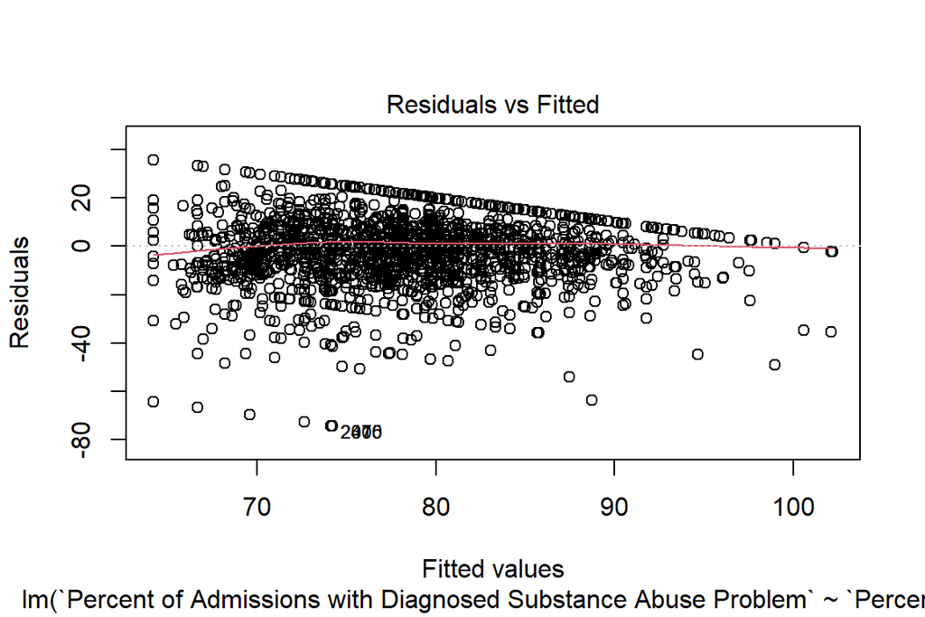

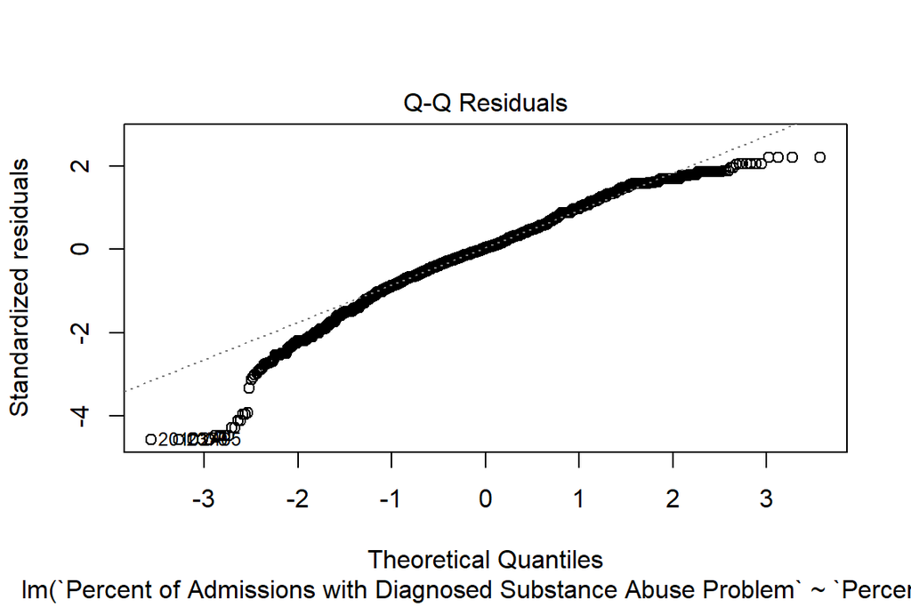

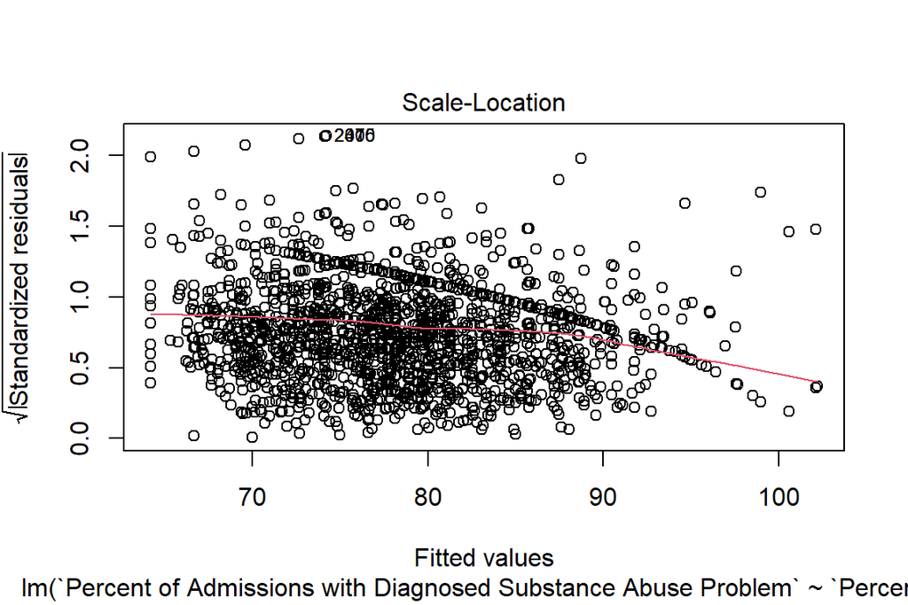

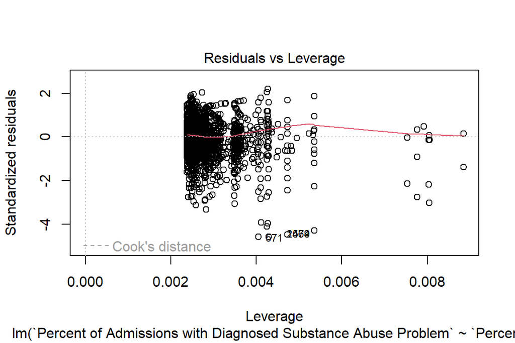

### 5.2 Full Model

This model includes all the variables as the baseline model, and also controls for county, gender, average TCU drug screen score, and number of drug screened admissions. There is also an interaction term between the percent of new admisssions with opioid use and year to control for if the percentage of new admissions with opioid use fluctuates between years.

```
##
## Call:
## lm(formula = `Percent of Admissions with Diagnosed Substance Abuse Problem` ~
##     `Percent of New Admissions with Opioid Use` + `Year Category` +
##         `Percent of New Admissions with Opioid Use` * `Year Category` +
##         `County Name` + Gender + `Average TCU Drug Screen Score` +
##         `Drug Screened Admissions`, data = pa_educ_add_mod)
##
## Residuals:
##     Min      1Q  Median      3Q     Max
## -37.296  -5.259  -0.405   4.770  45.568
##
## Coefficients:
##                                                                  Estimate
## (Intercept)                                                     21.547489
## `Percent of New Admissions with Opioid Use`                      0.021736
## `Year Category`2017                                              2.257029
## `Year Category`2018                                              2.883926
## `Year Category`2019                                              7.020831
## `Year Category`2020                                              6.544712
## `Year Category`2021                                              4.913989
## `Year Category`2022                                             -1.963444
## `County Name`Allegheny                                          -0.173348
## `County Name`Armstrong                                          -3.328241
## `County Name`Beaver                                             -2.368394
## `County Name`Bedford                                            -0.960839
## `County Name`Berks                                              -5.671143
## `County Name`Blair                                              -0.323269
## `County Name`Bradford                                           -2.387257
## `County Name`Bucks                                              -3.506680
## `County Name`Butler                                             -4.667748
## `County Name`Cambria                                            -0.601612
## `County Name`Cameron                                             0.360448
## `County Name`Carbon                                             -0.426914
## `County Name`Centre                                             -4.839728
## `County Name`Chester                                            -3.394430
## `County Name`Clarion                                            -1.749532
## `County Name`Clearfield                                          2.045537
## `County Name`Clinton                                            -2.738861
## `County Name`Columbia                                           -2.160364
```

[output cut: 304 more lines]

```
## GenderMale                                                       < 2e-16 ***
## `Average TCU Drug Screen Score`                                  < 2e-16 ***
## `Drug Screened Admissions`                                      0.470075
## `Percent of New Admissions with Opioid Use`:`Year Category`2017 0.203337
## `Percent of New Admissions with Opioid Use`:`Year Category`2018 0.007144 **
## `Percent of New Admissions with Opioid Use`:`Year Category`2019 1.17e-12 ***
## `Percent of New Admissions with Opioid Use`:`Year Category`2020 1.35e-07 ***
## `Percent of New Admissions with Opioid Use`:`Year Category`2021 8.63e-11 ***
## `Percent of New Admissions with Opioid Use`:`Year Category`2022 0.061484 .
## ---
## Signif. codes:  0 '***' 0.001 '**' 0.01 '*' 0.05 '.' 0.1 ' ' 1
##
## Residual standard error: 9.121 on 2722 degrees of freedom
## Multiple R-squared:  0.7485, Adjusted R-squared:  0.7408
## F-statistic: 97.61 on 83 and 2722 DF,  p-value: < 2.2e-16
```

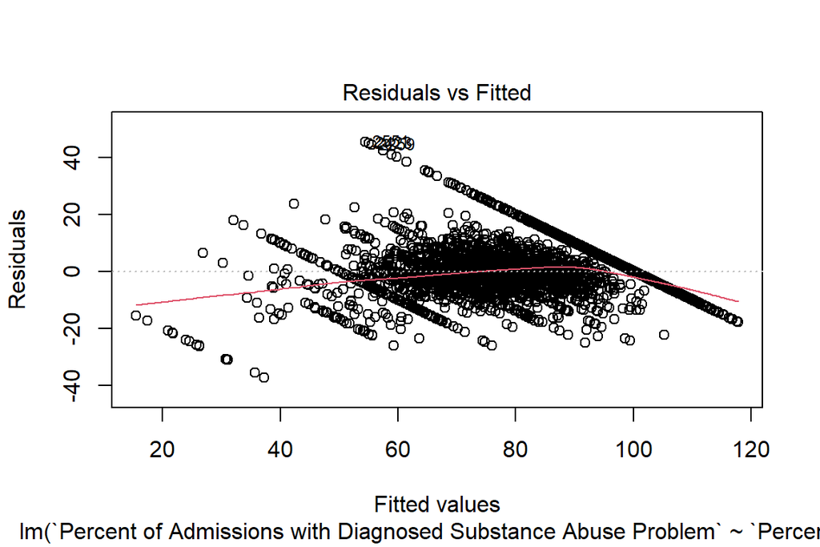

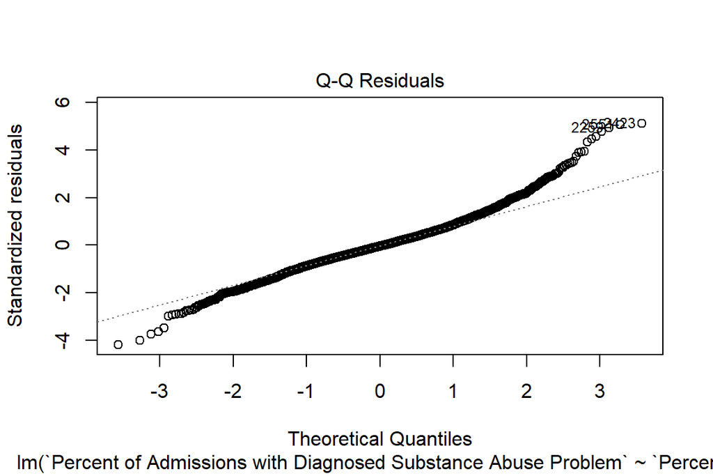

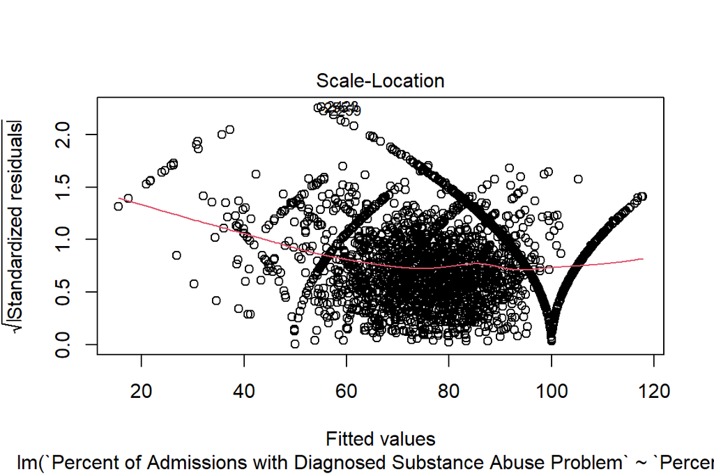

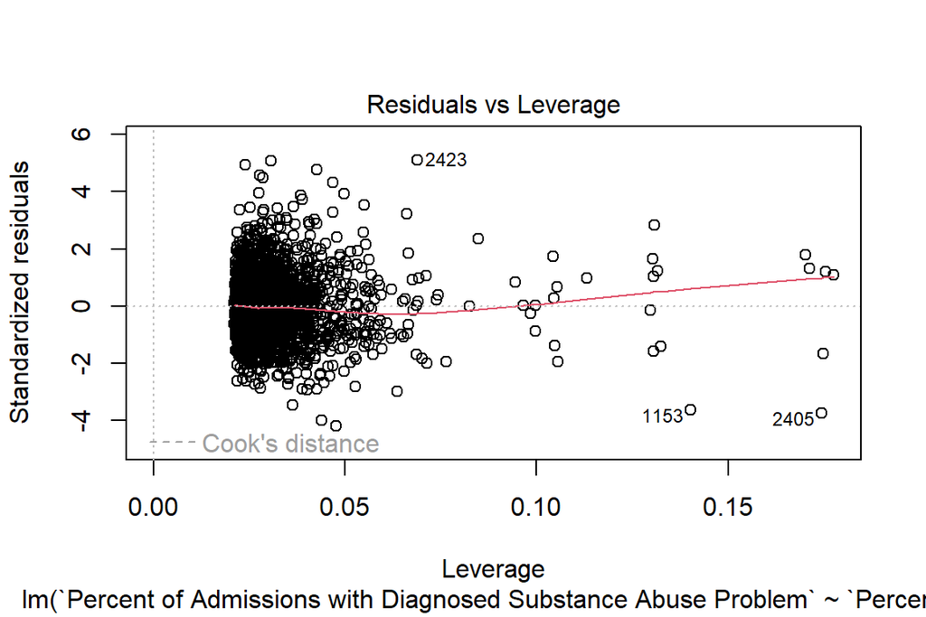

```
## there are higher-order terms (interactions) in this model
## consider setting type = 'predictor'; see ?vif
```

```
##                                                                    GVIF Df
## `Percent of New Admissions with Opioid Use`                    7.884563  1
## `Year Category`                                             2484.132755  6
## `County Name`                                                  2.858322 67
## Gender                                                         1.798365  1
## `Average TCU Drug Screen Score`                                1.753230  1
## `Drug Screened Admissions`                                     2.149161  1
## `Percent of New Admissions with Opioid Use`:`Year Category` 7091.984368  6
##                                                             GVIF^(1/(2*Df))
## `Percent of New Admissions with Opioid Use`                        2.807946
## `Year Category`                                                    1.918365
## `County Name`                                                      1.007868
## Gender                                                             1.341031
## `Average TCU Drug Screen Score`                                    1.324096
## `Drug Screened Admissions`                                         1.466002
## `Percent of New Admissions with Opioid Use`:`Year Category`        2.093617
```

Most of the variables in this model are significant at the p=0.05 level with the exception of the number of drug screened admissions and many of the counties. Additionally, the explanatory variable is also not significant, indicating that other variables in the model may be better predictors of the percent of admissions with a substance abuse problem. The residual plots for this model appear to have varying patterns that indicate they are not normally distributed. In the plot of the residuals versus the fitted values, there appear to be multiple diagnol lines as opposed to being randomly scattered. The right most prominent diagnol appears to be from counties that had a 100% of admissions with a substance abuse problem as the fitted value plus residual is equal to 100, so it is likely the other diagnols follow similar patterns for other values. There are no significant outliers in any of the plots that appear to have strong leverage over the model.

### 5.3 Adjusted Model

Summary table of significant tests

|  | Estimate | Std. Error | t value | Pr(>\|t\|) |
| --- | --- | --- | --- | --- |
| (Intercept) | 19.6287834 | 1.0624081 | 18.4757463 | 0.0000000 |
| `Percent of New Admissions with Opioid Use` | 0.0193734 | 0.0193822 | 0.9995470 | 0.3176165 |
| `Year Category`2017 | 1.9572979 | 1.1832963 | 1.6541063 | 0.0982184 |
| `Year Category`2018 | 2.8681610 | 1.1727996 | 2.4455678 | 0.0145238 |
| `Year Category`2019 | 7.0394353 | 1.1644163 | 6.0454625 | 0.0000000 |
| `Year Category`2020 | 6.5372357 | 1.2022455 | 5.4375213 | 0.0000001 |
| `Year Category`2021 | 4.8826818 | 1.2984125 | 3.7605012 | 0.0001731 |
| `Year Category`2022 | -1.8615562 | 1.3603266 | -1.3684626 | 0.1712775 |
| GenderMale | 4.6545334 | 0.4066244 | 11.4467647 | 0.0000000 |
| `Average TCU Drug Screen Score` | 10.6412236 | 0.1388692 | 76.6276538 | 0.0000000 |
| `Percent of New Admissions with Opioid Use`:`Year Category`2017 | -0.0234899 | 0.0256473 | -0.9158812 | 0.3598083 |
| `Percent of New Admissions with Opioid Use`:`Year Category`2018 | -0.0717912 | 0.0263904 | -2.7203541 | 0.0065616 |
| `Percent of New Admissions with Opioid Use`:`Year Category`2019 | -0.1884162 | 0.0262933 | -7.1659449 | 0.0000000 |
| `Percent of New Admissions with Opioid Use`:`Year Category`2020 | -0.1377066 | 0.0267775 | -5.1426190 | 0.0000003 |
| `Percent of New Admissions with Opioid Use`:`Year Category`2021 | -0.1713615 | 0.0267614 | -6.4033054 | 0.0000000 |
| `Percent of New Admissions with Opioid Use`:`Year Category`2022 | -0.0578862 | 0.0294037 | -1.9686675 | 0.0490901 |

Using a backward stepwise regression between the previous two models shows a final model with the variables “Average TCU Drug Screen Score”, Gender, and the interaction term between “Percent of New Admissions with opioid Use” and Year in addition to the “Percent of New Admissions with Opioid Use” and year.

### 5.4 Model Comparisons

##### 5.4.0.1 R-Squared of Baseline Model

```
## [1] 0.1759257
```

```
## [1] 0.7485047
```

##### 5.4.0.2 R-Square of Adjusted Model

```
## [1] 0.737607
```

Comparing the R-squared values of the models show the baseline model to have the lowest R-squared value and the full has the highest R-squared value. However, the adjusted model has a similar R-squared value as the model with the most control variables, so it terms of R-square it would be the best value.

##### 5.4.0.3 Five-Fold Validation Between Baseline and Full Models

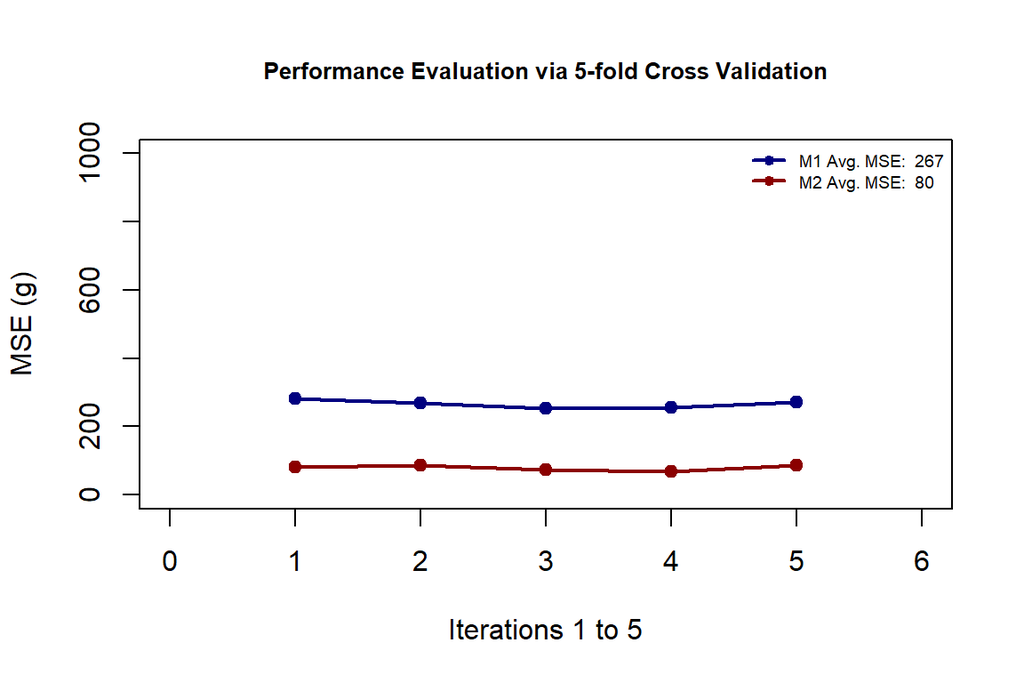

Completing a 5-fold cross validation between the first two models shows the model with more control variables (M2) to have a lower mean squared error than the baseline model (M1). The MSE is over three times larger on average for the baseline model, making it a worse predictor.

##### 5.4.0.4 Five-Fold Validation Between Full and Adjusted Models

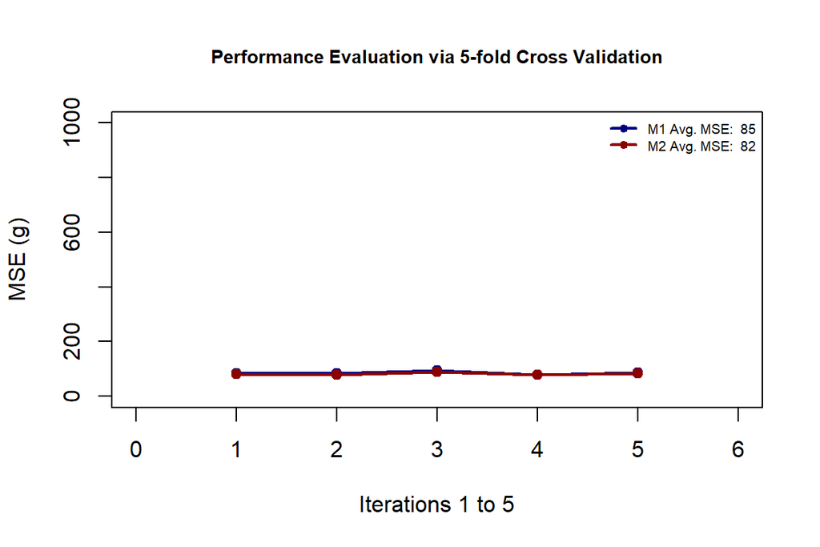

## 6 Logistic Models

To answer the question of if there is a relationship between if there is a high percentage of inmates with substance abuse and gender, a logistic model must be used. For this analysis a high percentage of inmates with substance abuse problem is considered to be 51% or higher to ensure a majority of the inmates have a substance abuse problem.

### 6.1 Baseline Logistic Model

```
##
## Call:
## lm(formula = `High Substance Abuse` ~ Male, data = pa_educ_add_mod)
##
## Residuals:
##      Min       1Q   Median       3Q      Max
## -0.94633  0.05367  0.05367  0.14172  0.14172
##
## Coefficients:
##             Estimate Std. Error t value Pr(>|t|)
## (Intercept) 0.858282   0.008383  102.38  < 2e-16 ***
## Male        0.088051   0.010844    8.12 6.93e-16 ***
## ---
## Signif. codes:  0 '***' 0.001 '**' 0.01 '*' 0.05 '.' 0.1 ' ' 1
##
## Residual standard error: 0.2817 on 2804 degrees of freedom
## Multiple R-squared:  0.02297,    Adjusted R-squared:  0.02262
## F-statistic: 65.93 on 1 and 2804 DF,  p-value: 6.931e-16
```

### 6.2 Full Logistic Model

Summary table of significant tests

|  | Estimate | Std. Error | t value | Pr(>\|t\|) |
| --- | --- | --- | --- | --- |
| (Intercept) | 0.2079491 | 0.0392117 | 5.3032387 | 0.0000001 |
| Male | 0.2013224 | 0.0233632 | 8.6170718 | 0.0000000 |
| `Year Category`2017 | 0.0235392 | 0.0235780 | 0.9983562 | 0.3181954 |
| `Year Category`2018 | 0.0205056 | 0.0235475 | 0.8708213 | 0.3839285 |
| `Year Category`2019 | -0.0180825 | 0.0240041 | -0.7533091 | 0.4513293 |
| `Year Category`2020 | -0.0565239 | 0.0265064 | -2.1324634 | 0.0330580 |
| `Year Category`2021 | -0.0843562 | 0.0263726 | -3.1986336 | 0.0013967 |
| `Year Category`2022 | -0.1060539 | 0.0278554 | -3.8073057 | 0.0001436 |
| `County Name`Allegheny | 0.0524859 | 0.0453830 | 1.1565097 | 0.2475742 |
| `County Name`Armstrong | -0.1018707 | 0.0499260 | -2.0404340 | 0.0414034 |
| `County Name`Beaver | -0.0413099 | 0.0482352 | -0.8564255 | 0.3918378 |
| `County Name`Bedford | -0.0128275 | 0.0469350 | -0.2733035 | 0.7846407 |
| `County Name`Berks | -0.0175307 | 0.0449988 | -0.3895825 | 0.6968758 |
| `County Name`Blair | 0.0037708 | 0.0441854 | 0.0853404 | 0.9319970 |
| `County Name`Bradford | -0.0486256 | 0.0455933 | -1.0665083 | 0.2862885 |
| `County Name`Bucks | -0.0066392 | 0.0446379 | -0.1487350 | 0.8817737 |
| `County Name`Butler | -0.0196540 | 0.0469329 | -0.4187683 | 0.6754185 |
| `County Name`Cambria | -0.0218452 | 0.0453770 | -0.4814152 | 0.6302601 |
| `County Name`Cameron | -0.2471648 | 0.0745450 | -3.3156466 | 0.0009263 |
| `County Name`Carbon | -0.0369615 | 0.0469413 | -0.7873974 | 0.4311178 |
| `County Name`Centre | -0.0637911 | 0.0482206 | -1.3229013 | 0.1859793 |
| `County Name`Chester | -0.0391661 | 0.0444715 | -0.8807022 | 0.3785568 |
| `County Name`Clarion | -0.0888499 | 0.0508383 | -1.7476950 | 0.0806296 |
| `County Name`Clearfield | 0.0592897 | 0.0442572 | 1.3396631 | 0.1804667 |
| `County Name`Clinton | -0.0800163 | 0.0498462 | -1.6052620 | 0.1085522 |
| `County Name`Columbia | -0.0716786 | 0.0473724 | -1.5130896 | 0.1303730 |
| `County Name`Crawford | -0.0858806 | 0.0458289 | -1.8739408 | 0.0610456 |
| `County Name`Cumberland | -0.0114988 | 0.0458366 | -0.2508653 | 0.8019372 |
| `County Name`Dauphin | 0.0909520 | 0.0446215 | 2.0382988 | 0.0416165 |
| `County Name`Delaware | 0.1023233 | 0.0452918 | 2.2592030 | 0.0239495 |

[output cut: 54 more lines]

```
## [1] 0.411891
```

##### 6.2.0.1 Full Logistic Model Variance Inflation Factor

```
## there are higher-order terms (interactions) in this model
## consider setting type = 'predictor'; see ?vif
```

```
##                                                    GVIF Df GVIF^(1/(2*Df))
## Male                                           7.485505  1        2.735965
## `Year Category`                              332.627988  6        1.622420
## `County Name`                                  2.569786 67        1.007068
## `Percent of New Admissions with Opioid Use`    1.988321  1        1.410078
## `Average TCU Drug Screen Score`                1.846694  1        1.358931
## `Drug Screened Admissions`                     2.181170  1        1.476878
## Male:`Year Category`                        1123.007762  6        1.795554
```

The full logsitic model measures the same relationship as the baseline logistic model, but also includes controls for year, county, percent of new admissions with opioid use, average TCU drug screen score, number of drug screened admissions along with an interaction term between gender and year. Including these controls raises the R-square to 0.4119, which is much better than the baseline model. However, not all terms appear significant and there is also high correlation between year and gender as indicated by the variance inflation factor (GVIF). The high correlation is likely due to the interaction term between year and gender.

### 6.3 Adjusted Logistic Model

Summary table of significant tests

|  | Estimate | Std. Error | t value | Pr(>\|t\|) |
| --- | --- | --- | --- | --- |
| (Intercept) | 0.2129998 | 0.0375761 | 5.6684926 | 0.0000000 |
| Male | 0.1956482 | 0.0105536 | 18.5385254 | 0.0000000 |
| `Year Category`2017 | 0.0028299 | 0.0151615 | 0.1866528 | 0.8519467 |
| `Year Category`2018 | -0.0037848 | 0.0152332 | -0.2484581 | 0.8037987 |
| `Year Category`2019 | -0.0176283 | 0.0154432 | -1.1414901 | 0.2537662 |
| `Year Category`2020 | -0.0422166 | 0.0161852 | -2.6083364 | 0.0091480 |
| `Year Category`2021 | -0.0911071 | 0.0161657 | -5.6358380 | 0.0000000 |
| `Year Category`2022 | -0.0789878 | 0.0171443 | -4.6072283 | 0.0000043 |
| `County Name`Allegheny | 0.0530945 | 0.0453990 | 1.1695079 | 0.2423012 |
| `County Name`Armstrong | -0.1062077 | 0.0499258 | -2.1273130 | 0.0334836 |
| `County Name`Beaver | -0.0422476 | 0.0482555 | -0.8754971 | 0.3813805 |
| `County Name`Bedford | -0.0130539 | 0.0469557 | -0.2780047 | 0.7810298 |
| `County Name`Berks | -0.0177370 | 0.0450167 | -0.3940098 | 0.6936046 |
| `County Name`Blair | 0.0005657 | 0.0441725 | 0.0128057 | 0.9897837 |
| `County Name`Bradford | -0.0488739 | 0.0456088 | -1.0715879 | 0.2840000 |
| `County Name`Bucks | -0.0078177 | 0.0446564 | -0.1750640 | 0.8610424 |
| `County Name`Butler | -0.0212559 | 0.0469436 | -0.4527958 | 0.6507318 |
| `County Name`Cambria | -0.0234901 | 0.0453746 | -0.5176927 | 0.6047147 |
| `County Name`Cameron | -0.2522689 | 0.0745135 | -3.3855458 | 0.0007204 |
| `County Name`Carbon | -0.0390382 | 0.0469406 | -0.8316507 | 0.4056789 |
| `County Name`Centre | -0.0648331 | 0.0482408 | -1.3439489 | 0.1790767 |
| `County Name`Chester | -0.0395985 | 0.0444928 | -0.8899986 | 0.3735451 |
| `County Name`Clarion | -0.0904954 | 0.0508501 | -1.7796498 | 0.0752446 |
| `County Name`Clearfield | 0.0570223 | 0.0442688 | 1.2880920 | 0.1978232 |
| `County Name`Clinton | -0.0841581 | 0.0498391 | -1.6885966 | 0.0914110 |
| `County Name`Columbia | -0.0751652 | 0.0473611 | -1.5870675 | 0.1126132 |
| `County Name`Crawford | -0.0862002 | 0.0458490 | -1.8800907 | 0.0602022 |
| `County Name`Cumberland | -0.0125071 | 0.0458440 | -0.2728187 | 0.7850132 |
| `County Name`Dauphin | 0.0919286 | 0.0446342 | 2.0595996 | 0.0395315 |
| `County Name`Delaware | 0.1019221 | 0.0453116 | 2.2493622 | 0.0245689 |
| `County Name`Elk | -0.0997669 | 0.0503350 | -1.9820584 | 0.0475729 |
| `County Name`Erie | 0.0379593 | 0.0443136 | 0.8566079 | 0.3917369 |
| `County Name`Fayette | 0.0660299 | 0.0443335 | 1.4893909 | 0.1365001 |
| `County Name`Forest | -0.1831677 | 0.0850278 | -2.1542086 | 0.0313111 |
| `County Name`Franklin | 0.0739035 | 0.0443336 | 1.6669862 | 0.0956319 |
| `County Name`Fulton | -0.0920582 | 0.0542471 | -1.6970153 | 0.0898078 |
| `County Name`Greene | -0.0551829 | 0.0529779 | -1.0416211 | 0.2976797 |
| `County Name`Huntingdon | -0.0478332 | 0.0456480 | -1.0478724 | 0.2947902 |
| `County Name`Indiana | -0.1361579 | 0.0504246 | -2.7002270 | 0.0069720 |
| `County Name`Jefferson | 0.0288035 | 0.0442737 | 0.6505786 | 0.5153733 |
| `County Name`Juniata | -0.2369207 | 0.0574029 | -4.1273284 | 0.0000378 |
| `County Name`Lackawanna | 0.0372995 | 0.0443615 | 0.8408075 | 0.4005295 |
| `County Name`Lancaster | 0.0457476 | 0.0443623 | 1.0312270 | 0.3025258 |
| `County Name`Lawrence | -0.1104928 | 0.0479468 | -2.3044857 | 0.0212702 |
| `County Name`Lebanon | -0.0296142 | 0.0458897 | -0.6453339 | 0.5187651 |
| `County Name`Lehigh | 0.0134539 | 0.0452422 | 0.2973756 | 0.7662024 |
| `County Name`Luzerne | -0.0091439 | 0.0445613 | -0.2051984 | 0.8374325 |
| `County Name`Lycoming | 0.0560556 | 0.0444735 | 1.2604257 | 0.2076236 |
| `County Name`Mckean | -0.0857959 | 0.0643557 | -1.3331510 | 0.1825936 |
| `County Name`McKean | -0.0798889 | 0.0529470 | -1.5088450 | 0.1314542 |
| `County Name`Mercer | -0.0589419 | 0.0461323 | -1.2776702 | 0.2014745 |
| `County Name`Mifflin | -0.0408821 | 0.0472235 | -0.8657165 | 0.3867218 |
| `County Name`Monroe | 0.0003907 | 0.0444782 | 0.0087841 | 0.9929920 |
| `County Name`Montgomery | 0.0716764 | 0.0451221 | 1.5884976 | 0.1122897 |
| `County Name`Montour | -0.1428905 | 0.0603516 | -2.3676340 | 0.0179716 |
| `County Name`Northampton | 0.0672424 | 0.0447679 | 1.5020208 | 0.1332075 |
| `County Name`Northumberland | 0.0037668 | 0.0487044 | 0.0773409 | 0.9383580 |
| `County Name`Perry | -0.1313088 | 0.0512482 | -2.5622141 | 0.0104540 |
| `County Name`Philadelphia | 0.0722133 | 0.0501119 | 1.4410401 | 0.1496881 |
| `County Name`Pike | -0.0416566 | 0.0469593 | -0.8870792 | 0.3751144 |
| `County Name`Potter | -0.1530827 | 0.0513193 | -2.9829471 | 0.0028802 |
| `County Name`Schuylkill | 0.0049752 | 0.0443083 | 0.1122865 | 0.9106045 |
| `County Name`Snyder | -0.0104745 | 0.0451446 | -0.2320217 | 0.8165386 |
| `County Name`Somerset | -0.0767096 | 0.0464839 | -1.6502409 | 0.0990088 |
| `County Name`Sullivan | -0.3918861 | 0.0965065 | -4.0607216 | 0.0000503 |
| `County Name`Susquehanna | -0.1541091 | 0.0583297 | -2.6420328 | 0.0082881 |
| `County Name`Tioga | -0.1934045 | 0.0543190 | -3.5605309 | 0.0003764 |
| `County Name`Union | -0.0706540 | 0.0490104 | -1.4416116 | 0.1495268 |
| `County Name`Venango | -0.0641501 | 0.0449103 | -1.4284043 | 0.1532900 |
| `County Name`Warren | -0.0401746 | 0.0466895 | -0.8604619 | 0.3896101 |
| `County Name`Washington | -0.0047481 | 0.0444431 | -0.1068353 | 0.9149275 |
| `County Name`Wayne | -0.1351633 | 0.0513451 | -2.6324467 | 0.0085250 |
| `County Name`Westmoreland | 0.0207702 | 0.0448641 | 0.4629587 | 0.6434309 |
| `County Name`Wyoming | -0.1266630 | 0.0479802 | -2.6399026 | 0.0083402 |
| `County Name`York | 0.0347759 | 0.0448173 | 0.7759497 | 0.4378460 |
| `Percent of New Admissions with Opioid Use` | -0.0008363 | 0.0002073 | -4.0340035 | 0.0000563 |
| `Average TCU Drug Screen Score` | 0.1231702 | 0.0035125 | 35.0665926 | 0.0000000 |
| `Drug Screened Admissions` | 0.0005621 | 0.0001870 | 3.0058131 | 0.0026729 |

```
## [1] 0.4099649
```

```
##                                                 GVIF Df GVIF^(1/(2*Df))
## Male                                        1.525788  1        1.235228
## `Year Category`                             1.220894  6        1.016771
## `County Name`                               2.443029 67        1.006688
## `Percent of New Admissions with Opioid Use` 1.499744  1        1.224640
## `Average TCU Drug Screen Score`             1.745190  1        1.321057
## `Drug Screened Admissions`                  2.143811  1        1.464176
```

To get the adjusted logistic model, I conducted a stepwise regression between the baseline logistic model and the full logistic model. This adjusted model measures the relation between a high percentage of admisssions with a substance abuse problem and gender while controlling for controls for year, county, percent of new admissions with opioid use, average TCU drug screen score, and number of drug screened admissions. With a similar R-square value to the full logistic model, and no severe correlation between variables, the adjusted logistic regression model appears to be better than the full logsitic model.

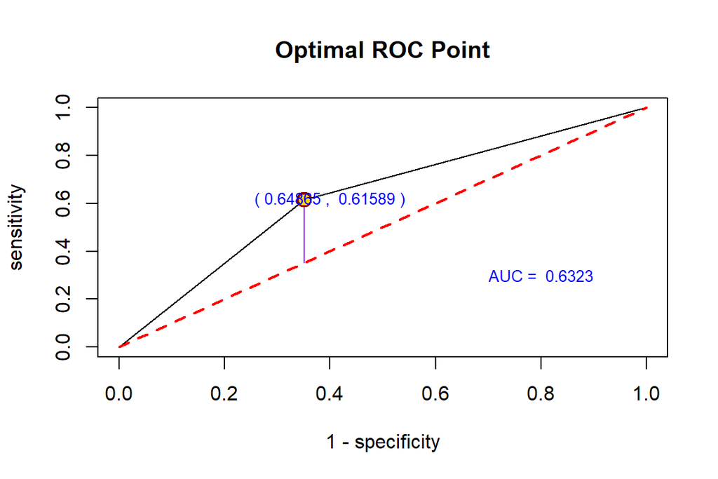

##### 6.3.0.1 5-fold Cross Validation for Baseline Logistic Model

```
## [1] 0.5201760 0.7485714 0.5968546 0.5671071 0.6419098
```

```
## [1] 0.6149238
```

##### 6.3.0.2 5-fold Cross Validation for Full Logistic Model

```
## [1] 0.9879868 0.9916667 0.9846154 0.9902173 0.9926276
```

```
## [1] 0.9894227
```

##### 6.3.0.3 5-fold Cross Validation for Adjusted Logistic Model

```
## [1] 0.9887349 0.9892381 0.9846806 0.9882680 0.9922765
```

```
## [1] 0.9886396
```